# Sung Lee Assignment 2: SQL and R

Sung Lee

2/6/2020

[Assignment on RPubs](https://rpubs.com/logicalschema/data607_week2)  
[Rmd on Github](https://github.com/logicalschema/DATA607/blob/master/week2/SungLeeAssignment2.Rmd)

## Setup: Recreating the database

The database created for this assignment is called movies. A `mysqldump` of the database was taken from a MariaDB Server 5.5.64. However, the dump would be compatible with a MySQL server. To recreate the database, one would only need to create a new database `CREATE DATABASE my_new_db` (where `my_new_db` is the name of your desired database) with an account that has privileges to create databases and import the database scheme and data by executing the command `mysql -u my_username -p my_new_db < movie.sql` (where `my_username` is a user account that has privileges for `my_new_db`). This will recreate the database in `my_new_db`.

## E-R Diagram: Movies Database

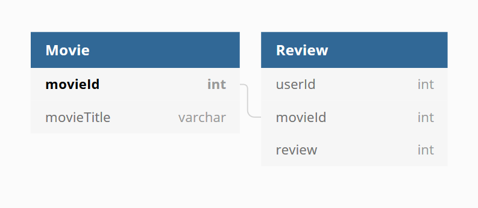

## R MySQL Connection and Loading the Data

The following code calls the RMySQL library and creates a connection to a locally hosted MySQL database. After the connection is created, it loads the data into an R dataframe. If a moviegoer has not seen a movie, I stored the value as `NULL` on MySQL. When the data is imported into R, the `NULL` is listed as an `NA`.

```r
library(RMySQL)
db_user <- 'sslee'
db_password <- 'password#2020'
db_name <- 'movies'
db_host <- '192.168.148.128'
db_port <- 3306


mydb <- dbConnect(MySQL(), user = db_user, password = db_password, dbname = db_name, host = db_host, port = db_port)


ratingsData <- dbGetQuery(mydb,
                          "SELECT A.userId, A.review, B.movieTitle
                           FROM Movie AS B RIGHT JOIN Review AS A
                           ON A.movieId = B.movieId"
                          )

ratingsData
```

| userId | review | movieTitle |
| --- | --- | --- |
| 1 | 5 | Little Women |
| 1 | NA | 1917 |
| 1 | NA | Ford v Ferrari |
| 1 | 2 | Joker |
| 1 | NA | Once Upon a Time in Hollywood |
| 1 | 4 | Parasite |
| 2 | NA | Little Women |
| 2 | NA | 1917 |
| 2 | NA | Ford v Ferrari |
| 2 | 5 | Joker |

[output cut: 44 more lines]

## Visualization of the Reviews

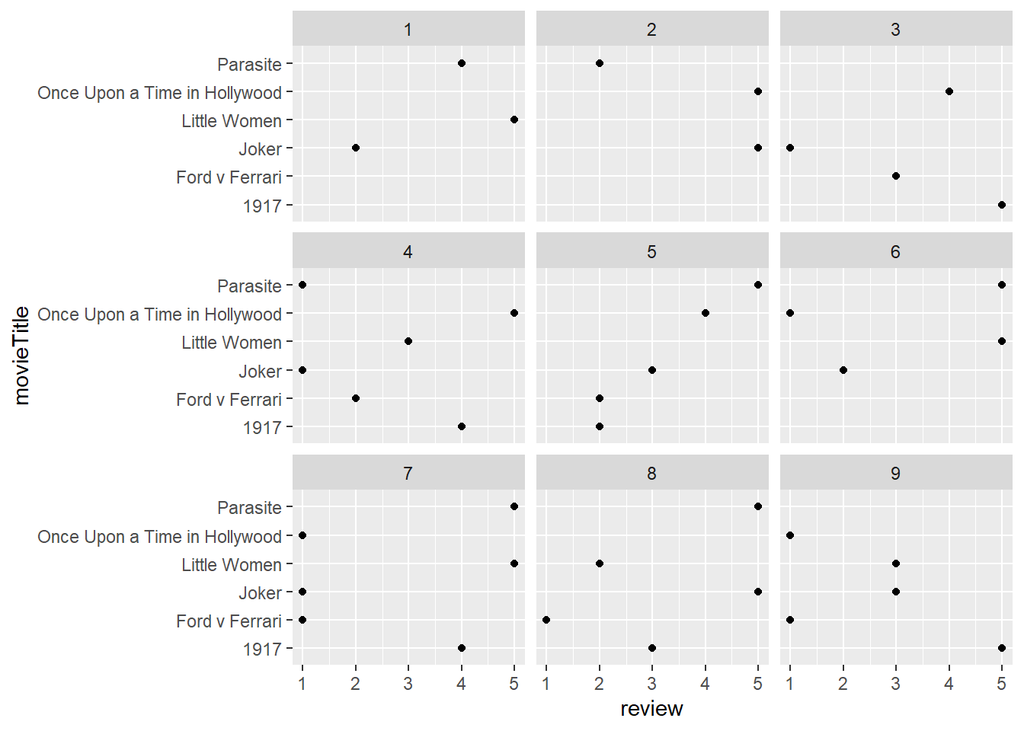

```r
library(ggplot2)

qplot(review, movieTitle, data = ratingsData, facets = ~userId)
```

[output not shown]

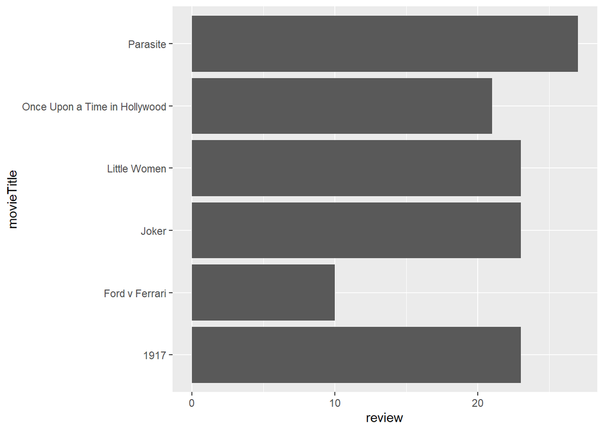

```r
ggplot(ratingsData, aes(x=movieTitle, y=review)) +
  geom_bar(stat = "identity") +
  coord_flip()
```